# Boosting Machine Learning

Daniel Navarro

2025-08-15

# Abstract

Boosting is a popular modeling method, consisting in recurring runs over previous models to improve performance, in this ocassion will check tree boosting performance on kaggle’s https://www.kaggle.com/datasets/rohitgrewal/spotify-youtube-data?resource=download.

As described in the data webpage: ‘This dataset shows how popular songs perform on both Spotify and YouTube. It includes useful details about each song, like its name, artist, how many times it was played on Spotify, how many views it got on YouTube, and several audio features like danceability, energy, loudness, and tempo.’

The data is not real, proves not consistent and its source is not detailed in kaggle, however is a dataset useful for the test of a boosting model. The results should not be considered outside of the domain of this data.

Executing a Lasso linear regression provides a simple model with a low Media Square Error (MSE), after selecting the best lambda for optimal result it help taking out variables that are not useful in the prediction of the desired output variable, Likes.

Boosting a regression tree, thought keeps all variables that makes the model a bit more complex generated a improvement of 43% reduction in MSE.

In the following parts we will focus more in the analysis and results than the code, therefore the code is not shown in the document.

# Exploratory Data Analysis

This is the description of the main Features/Columns available in the dataset:

```
Track: The name of the song
Artist: The person or band who performed the song
Stream: Total number of times the song was streamed on Spotify
Youtube Views: Total number of views the song has on YouTube
Danceability: Score showing how suitable the track is for dancing (0 to 1)
Energy: Score representing how energetic or intense the song is (0 to 1)
Key: The musical key of the track (number from 0 to 11)
Loudness: The loudness of the song in decibels (dB)
Speechiness: Tells how much spoken words are in the track
Acousticness: Tells if the track is mostly acoustic or not
Instrumentalness: Predicts if the song has no vocals
Liveness: Indicates if the song was recorded in front of a live audience
Valence: Measures how happy or positive the song sounds
Tempo: The speed of the song in beats per minute (BPM)
Duration_ms: Length of the track in milliseconds
Year: The year the song was released
```

## Correlation check between Likes and other paramaters

### Danceability

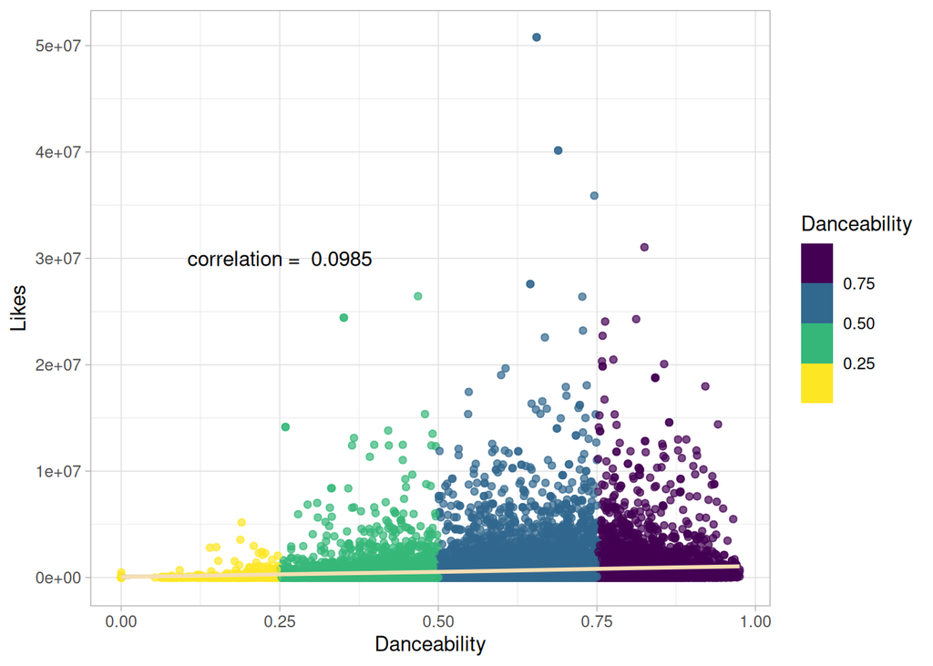

### Energy

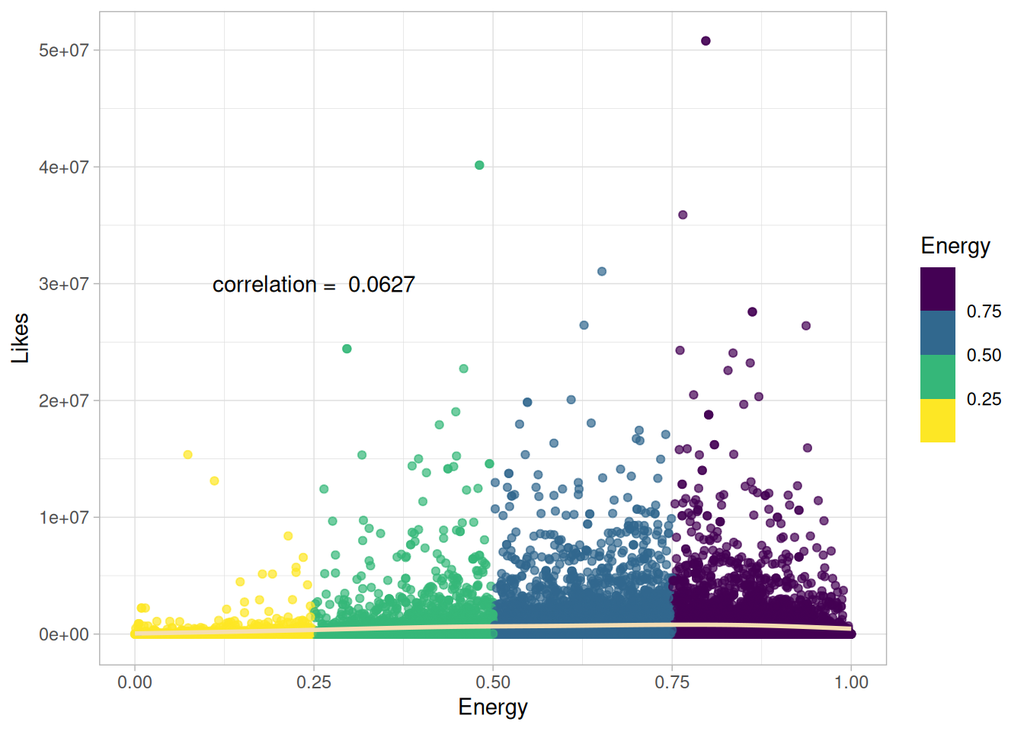

### Loudness

[figure not shown]

### Speechiness

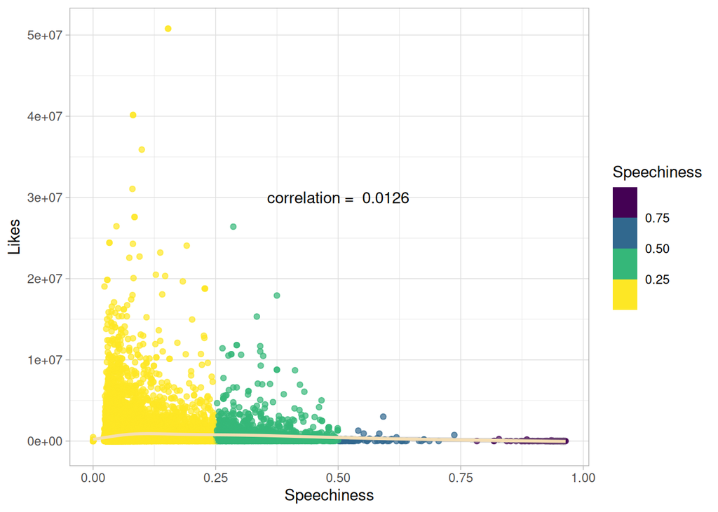

### Acousticness

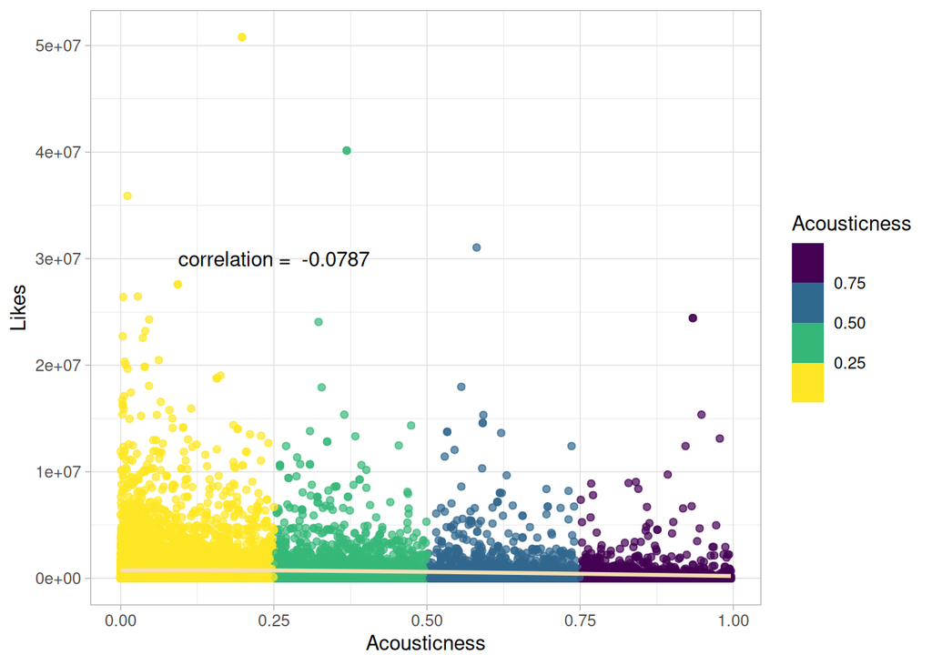

### Instrumentalness

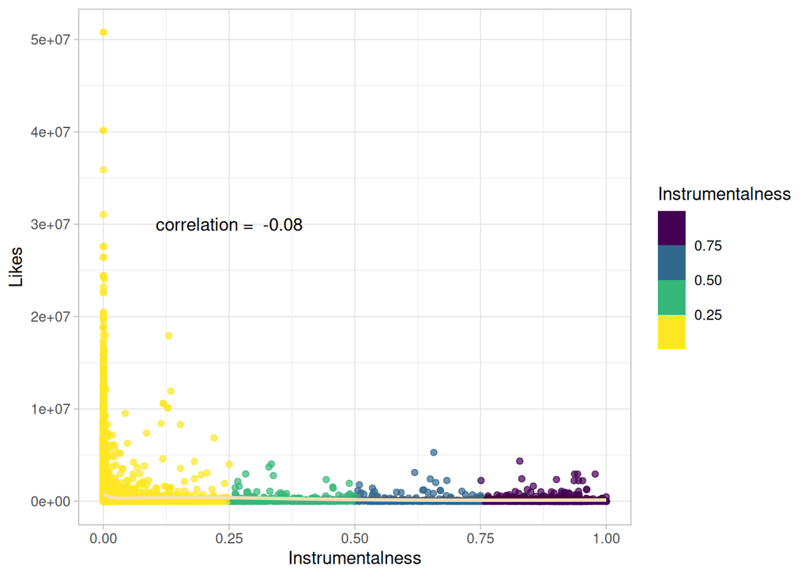

### Liveness

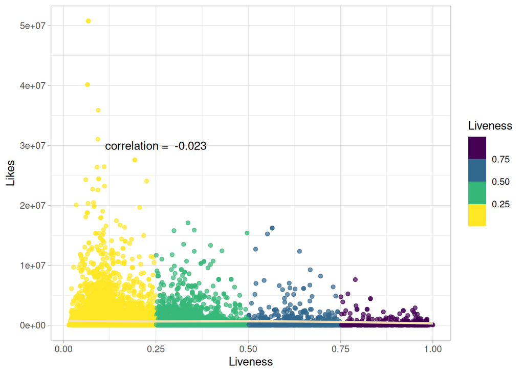

### Valence

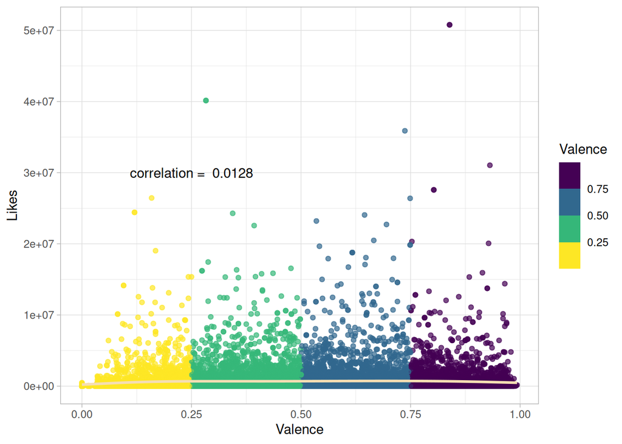

### Tempo

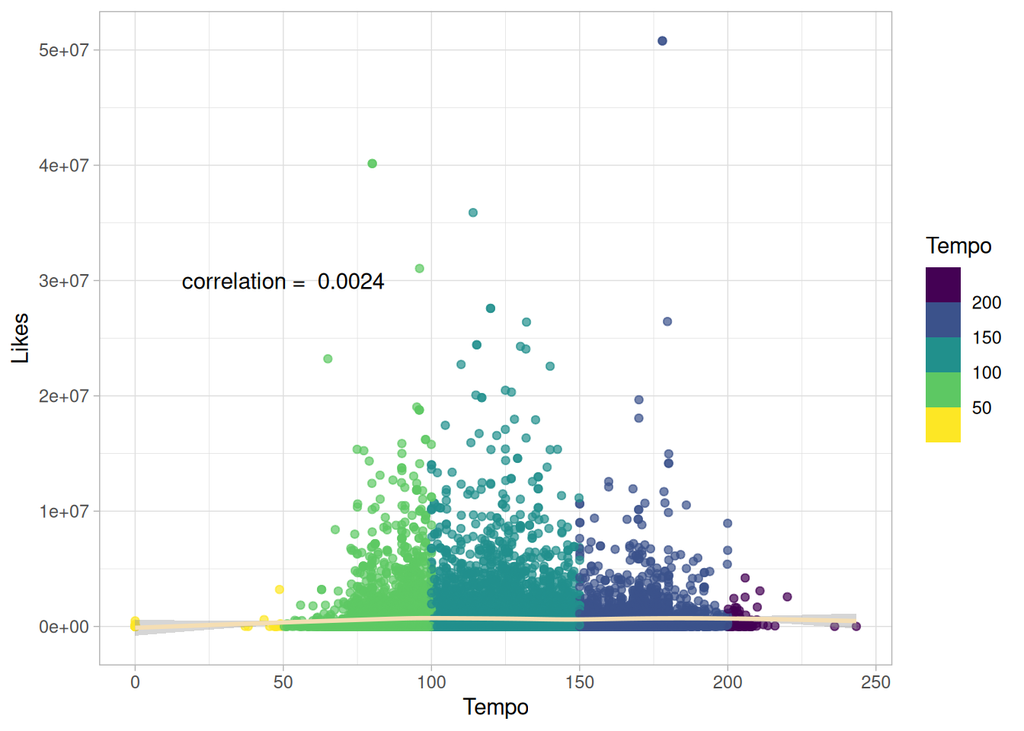

### Duration ms

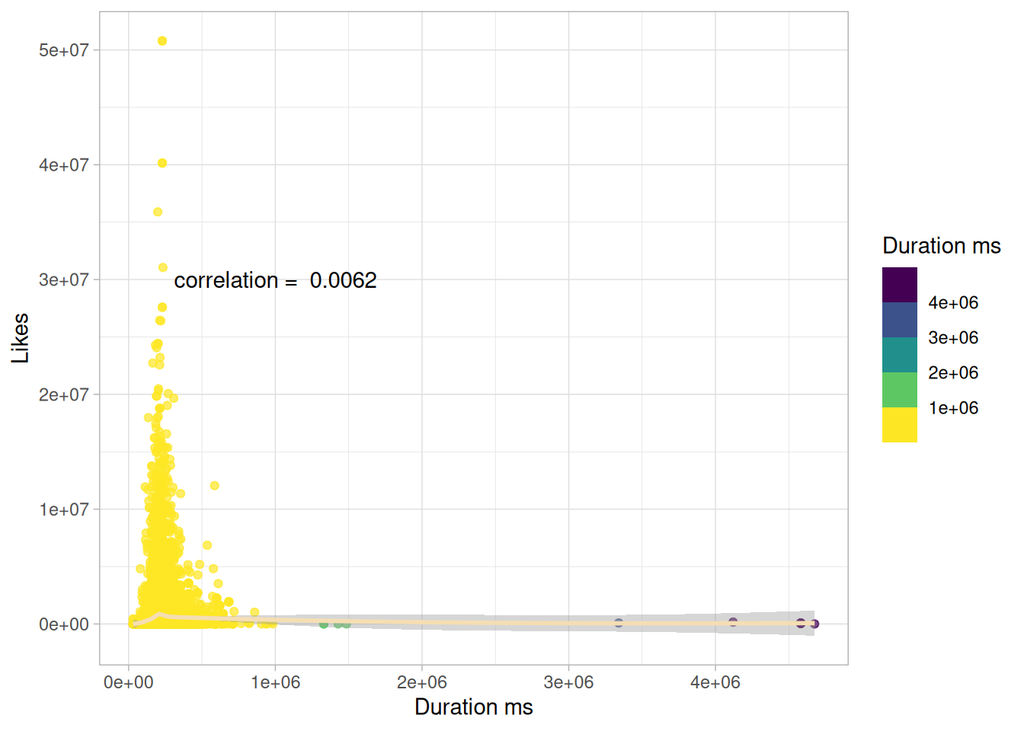

### Views

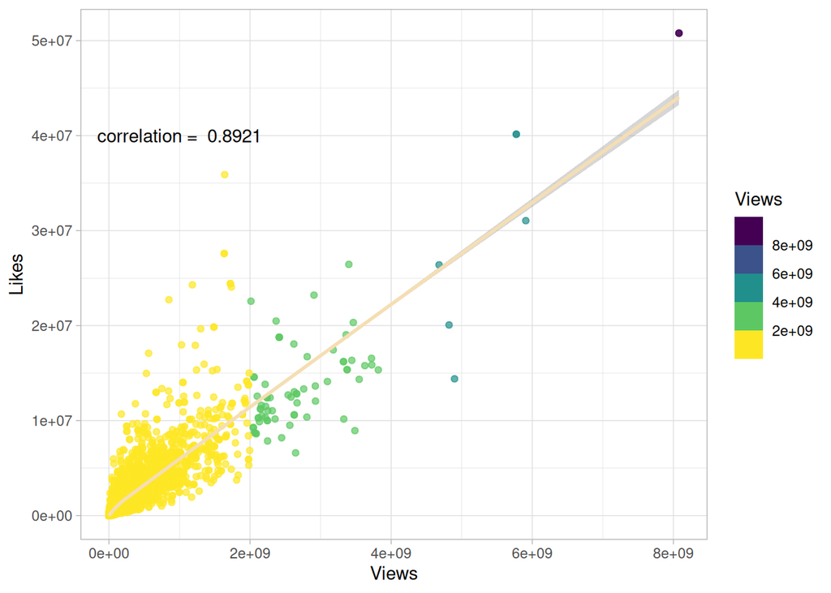

# Modeling. Lineal regression and Boosting

## Goal

The goal is to predict the number of Likes a son can receive based on parameters like tone, duration, loudness, danceability, views etc.

## Lineal Regression. Lasso.

A Lasso regression model yields a Mean Square Error (MSE) of 7.1379697^{11} and, as seen below drops 5 of the 25 coefficients as they are less important to explain the number of Likes a song receives.

| Parameter | Value |
| --- | --- |
| (Intercept) | 143789.365398032 |
| (Intercept) | 0 |
| Danceability | 242676.5906721252 |
| Energy | -55113.50542797866 |
| Key1 | 4226.585575752963 |
| Key2 | 0 |
| Key3 | -44.32366242752477 |
| Key4 | 20327.8635002016 |
| Key5 | 0 |
| Key6 | 5359.605796904096 |

[output cut: 15 more lines]

## Boosting regression tree

Boosting a regression tree, that goes beyond linearity finds a different set of parameter explanation of the output variable (Likes) but also a significantly lower SME of 4.0778801^{11}, this is 0.5712941 or a roughly 43% of reduction in SME with the following variable values.

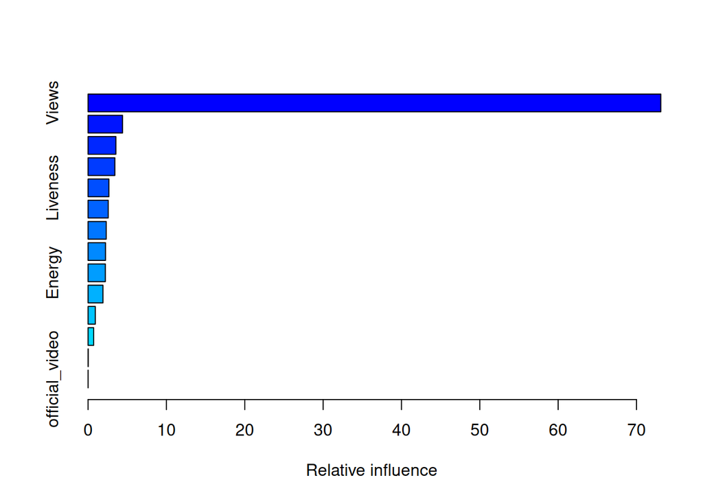

|  | var | rel.inf |
| --- | --- | --- |
| Views | Views | 73.103207517 |
| Duration_ms | Duration_ms | 4.399151594 |
| Speechiness | Speechiness | 3.550140600 |
| Tempo | Tempo | 3.416811302 |
| Liveness | Liveness | 2.658935383 |
| Valence | Valence | 2.569194110 |
| Loudness | Loudness | 2.314426890 |
| Acousticness | Acousticness | 2.223234027 |
| Energy | Energy | 2.204882661 |
| Danceability | Danceability | 1.896528276 |

[output cut: 4 more lines]

```r
datatable(as.matrix(summary(boost.data)))
```